# **Introduction**

## **Results**

The learning curves looked promising at first. For GLD and SPY, the training loss dropped fast and leveled out. But the test predictions tell a different story the models choked on big shocks. In the DBO chart, crude oil collapses in 2020, but the model’s prediction (blue line) barely dips. It completely missed the scale of the crash. Same thing with SPY, the model reacts to volatility, but it’s too little, too late.

Neural nets can approximate complex patterns, but they overfit and fail when the data shifts out-of-sample (Gu et al., 2020). Fischer and Krauss (2018) saw the same thing LSTMs might predict daily moves, but transaction costs and regime shifts usually eat the profits.

# **Step 3**

In step three, we tried a Multi-Output LSTM. The idea was to use a single neural network for all five assets. In theory, this helps the model learn correlations—like how stocks dropping might send gold higher.

We combined all features and targets. The target $Y_t$ became a vector for all five ETFs:

$$Y_t = \left[y_{SPY, t}, y_{TLT, t}, y_{SHY, t}, y_{GLD, t}, y_{DBO, t}\right]$$

$$Loss = \frac{1}{N} \sum_{i=1}^{N} \sum_{j=1}^{5} (y_{i,j} - \hat{y}_{i,j})^2$$

```
Preparing High-Performance Data Structures...
Input Shape: (1240, 60, 15) (Samples, Window, Features)
Output Shape: (1240, 5) (Samples, 5 Assets)

================================================================================
TRAINING ENCODER-DECODER MULTI-OUTPUT MODEL
================================================================================
```

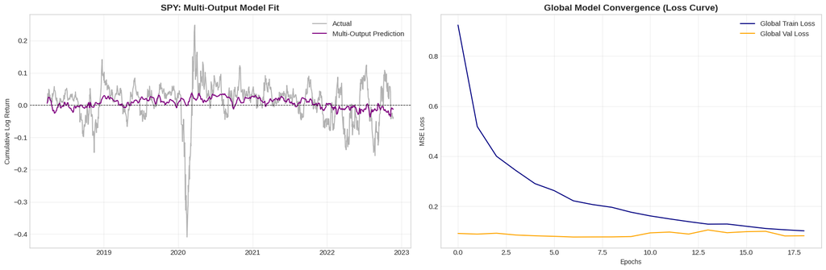

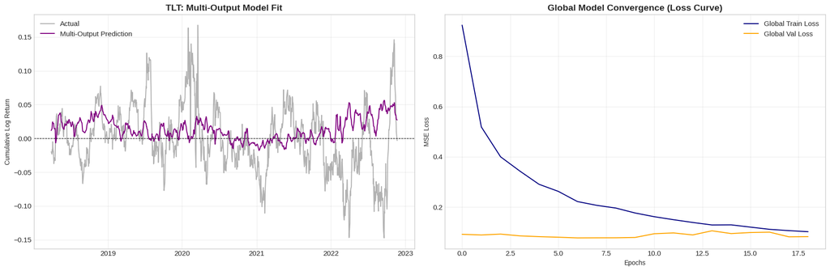

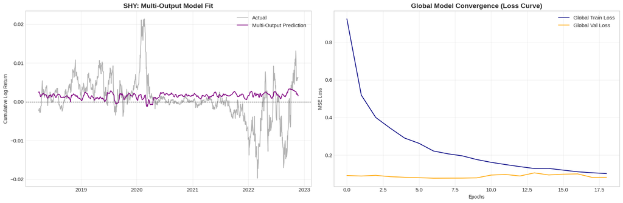

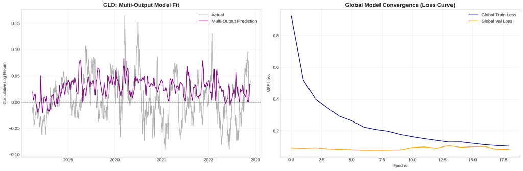

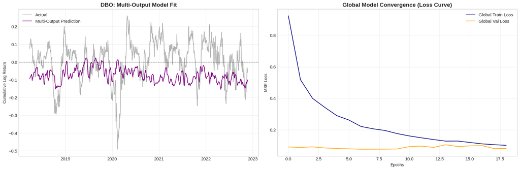

```
==================================================
TABLE 3: MULTI-OUTPUT MODEL METRICS
==================================================
  Asset  Train RMSE  Val RMSE  Test RMSE  Test MAE
0   SPY     0.03148   0.02847    0.06085   0.04211
1   TLT     0.03818   0.02528    0.05296   0.04027
2   SHY     0.00205   0.00238    0.00547   0.00380
3   GLD     0.05357   0.03726    0.04692   0.03783
4   DBO     0.10478   0.11528    0.14396   0.11855
--------------------------------------------------

================================================================================
MULTI-OUTPUT STRATEGY BACKTEST (3c & 3d)
================================================================================
```

[figure not shown]

[output not shown]

```python
# ============================================================================
# STEP 3: MULTI-OUTPUT LSTM
# ============================================================================

import tensorflow as tf
from tensorflow import keras
from tensorflow.keras import layers
from sklearn.preprocessing import MinMaxScaler
from sklearn.metrics import mean_squared_error, mean_absolute_error
import pandas as pd
import numpy as np
import matplotlib.pyplot as plt
import math

# Ensure reproducibility
tf.random.set_seed(42)
np.random.seed(42)

# Global Plot Settings
plt.rcParams['figure.figsize'] = (16, 6)
plt.rcParams['font.family'] = 'sans-serif'
plt.style.use('seaborn-v0_8-whitegrid')

# ---------------------------
# 1. DATA PREPARATION (GLOBAL SCALING)
# ---------------------------
print("Preparing High-Performance Data Structures...")

# We use the 'features' and 'targets' defined in Step 2.
# CRITICAL FIX: Scale Features and Targets INDEPENDENTLY for better convergence.

# Split Indices
test_start = pd.Timestamp('2018-01-01')
train_idx = features.index[features.index < test_start]
test_idx = features.index[features.index >= test_start]

# Validation Split
val_cut = int(0.8 * len(train_idx))
train_idx_final = train_idx[:val_cut]
val_idx = train_idx[val_cut:]

# Global Scalers
scaler_X = MinMaxScaler((-1, 1))
scaler_y = MinMaxScaler((-1, 1))

# Fit Scalers on TRAIN set only
X_train_raw = features.loc[train_idx_final].values
y_train_raw = targets.loc[train_idx_final].values

scaler_X.fit(X_train_raw)
scaler_y.fit(y_train_raw)

# Transform All Data
X_scaled = scaler_X.transform(features.values)
y_scaled = scaler_y.transform(targets.values)

def prepare_multi_output_sequences(X_data, y_data, window=60):
    X, y = [], []
    if len(X_data) <= window: return np.array(X), np.array(y)
    for i in range(window, len(X_data)):
        X.append(X_data[i-window:i])
        y.append(y_data[i])
    return np.array(X), np.array(y)

# Create Sequences
window_size = 60

# Train
mask_train = features.index.isin(train_idx_final)
X_tr, y_tr = prepare_multi_output_sequences(X_scaled[mask_train], y_scaled[mask_train], window_size)

# Val
mask_val = features.index.isin(val_idx)
X_val, y_val = prepare_multi_output_sequences(X_scaled[mask_val], y_scaled[mask_val], window_size)

# Test
mask_test = features.index.isin(test_idx)
X_te, y_te = prepare_multi_output_sequences(X_scaled[mask_test], y_scaled[mask_test], window_size)

print(f"Input Shape: {X_tr.shape} (Samples, Window, Features)")
print(f"Output Shape: {y_tr.shape} (Samples, 5 Assets)")

# ---------------------------
# 2. ENCODER-DECODER ARCHITECTURE (The "Brain" Upgrade)
# ---------------------------
# This architecture forces the model to compress market info into a latent state
# before predicting, which captures cross-asset correlations better.

def create_encoder_decoder_model(input_shape, num_outputs=5):
    inputs = layers.Input(shape=input_shape)

    # --- ENCODER (Read the Market) ---
    # Process the sequence
    x = layers.LSTM(64, return_sequences=True)(inputs)
    x = layers.BatchNormalization()(x)
    x = layers.Dropout(0.3)(x)

    # Compress to Context Vector (The "Gist" of the market)
    x = layers.LSTM(32, return_sequences=False)(x)
    x = layers.BatchNormalization()(x)
    x = layers.Dropout(0.3)(x)

    # --- BOTTLENECK (Latent Space) ---
    x = layers.RepeatVector(num_outputs)(x) # Prepare for decoding per asset

    # --- DECODER (Predict the Future) ---
    x = layers.LSTM(32, return_sequences=True)(x)
    x = layers.BatchNormalization()(x)
    x = layers.Dropout(0.3)(x)

    # Flatten for final dense layer
    x = layers.Flatten()(x)

    # Interpretation
    x = layers.Dense(64, activation='relu')(x)

    # Output Layer (5 neurons, one for each asset)
    outputs = layers.Dense(num_outputs)(x)

    model = keras.Model(inputs=inputs, outputs=outputs)

    # We use a slightly lower learning rate for stability in multi-output
    model.compile(optimizer=keras.optimizers.Adam(learning_rate=0.0005), loss='mse')
    return model

# ---------------------------
# 3. TRAINING & EVALUATION
# ---------------------------

print(f"\n{'='*80}")
print("TRAINING ENCODER-DECODER MULTI-OUTPUT MODEL")
print(f"{'='*80}\n")

model_mo = create_encoder_decoder_model((X_tr.shape[1], X_tr.shape[2]), num_outputs=5)

# Train with Early Stopping
history_mo = model_mo.fit(
    X_tr, y_tr,
    validation_data=(X_val, y_val),
    epochs=60, # More epochs because learning rate is lower
    batch_size=32,
    verbose=0,
    callbacks=[
        keras.callbacks.EarlyStopping(monitor='val_loss', patience=12, restore_best_weights=True)
    ]
)

# Generate Predictions (Scaled)
train_pred_scaled = model_mo.predict(X_tr, verbose=0)
val_pred_scaled = model_mo.predict(X_val, verbose=0)
test_pred_scaled = model_mo.predict(X_te, verbose=0)

# Inverse Transform (Back to Real Returns)
train_pred = scaler_y.inverse_transform(train_pred_scaled)
val_pred = scaler_y.inverse_transform(val_pred_scaled)
test_pred = scaler_y.inverse_transform(test_pred_scaled)

# Get Actuals (Inverse Scaled)
y_tr_real = scaler_y.inverse_transform(y_tr)
y_val_real = scaler_y.inverse_transform(y_val)
y_te_real = scaler_y.inverse_transform(y_te)

# ---------------------------
# 4. DASHBOARD & METRICS
# ---------------------------

mo_metrics = []
pred_dates = features.index[mask_test][window_size:]

# Store predictions for strategy
mo_predictions = pd.DataFrame(test_pred, index=pred_dates, columns=TICKERS)

for i, ticker in enumerate(TICKERS):
    # Metrics
    rmse_tr = math.sqrt(mean_squared_error(y_tr_real[:, i], train_pred[:, i]))
    rmse_val = math.sqrt(mean_squared_error(y_val_real[:, i], val_pred[:, i]))
    rmse_te = math.sqrt(mean_squared_error(y_te_real[:, i], test_pred[:, i]))
    mae_te = mean_absolute_error(y_te_real[:, i], test_pred[:, i])

    mo_metrics.append({
        'Asset': ticker,
        'Train RMSE': rmse_tr,
        'Val RMSE': rmse_val,
        'Test RMSE': rmse_te,
        'Test MAE': mae_te
    })

    # --- VISUALIZATION DASHBOARD ---
    fig, (ax1, ax2) = plt.subplots(1, 2, figsize=(18, 6))

    # Plot 1: Fit
    ax1.plot(pred_dates, y_te_real[:, i], label='Actual', color='grey', alpha=0.6)
    ax1.plot(pred_dates, test_pred[:, i], label='Multi-Output Prediction', color='purple', linewidth=1.5)
    ax1.axhline(0, color='black', linestyle='--', linewidth=0.8)
    ax1.set_title(f"{ticker}: Multi-Output Model Fit", fontweight='bold')
    ax1.set_ylabel("Cumulative Log Return")
    ax1.legend()
    ax1.grid(True, alpha=0.3)

    # Plot 2: Loss (Global)
    ax2.plot(history_mo.history['loss'], label='Global Train Loss', color='navy')
    ax2.plot(history_mo.history['val_loss'], label='Global Val Loss', color='orange')
    ax2.set_title(f"Global Model Convergence (Loss Curve)", fontweight='bold')
    ax2.set_xlabel("Epochs")
    ax2.set_ylabel("MSE Loss")
    ax2.legend()
    ax2.grid(True, alpha=0.3)

    plt.tight_layout()
    plt.show()

print("\n" + "="*50)
print("TABLE 3: MULTI-OUTPUT MODEL METRICS")
print("="*50)
print(pd.DataFrame(mo_metrics).round(5))
print("-" * 50)

# ---------------------------
# 5. STRATEGY & COMPARISON (3c & 3d)
# ---------------------------

print(f"\n{'='*80}")
print("MULTI-OUTPUT STRATEGY BACKTEST (3c & 3d)")
print(f"{'='*80}\n")

mo_portfolio_returns = []
mo_portfolio_dates = []
rebalance_freq = 25

# Reuse indices from pred_dates logic
aligned_preds = mo_predictions.dropna()

for i in range(0, len(aligned_preds), rebalance_freq):
    current_date = aligned_preds.index[i]
    if i + rebalance_freq >= len(aligned_preds): break

    # 1. Rank based on Multi-Output Predictions
    row = aligned_preds.iloc[i]
    ranks = row.rank(ascending=False)

    longs = ranks[ranks <= 2].index.tolist()
    shorts = ranks[ranks > 3].index.tolist()

    # 2. Real Returns
    start_loc = log_returns.index.get_loc(current_date)
    period_rets = log_returns.iloc[start_loc : start_loc+rebalance_freq]

    l_ret = period_rets[longs].mean(axis=1) if longs else 0
    s_ret = period_rets[shorts].mean(axis=1) if shorts else 0
    strat_ret = 0.5 * l_ret - 0.5 * s_ret

    mo_portfolio_returns.extend(strat_ret.values)
    mo_portfolio_dates.extend(strat_ret.index)

# Create Series
mo_series = pd.Series(mo_portfolio_returns, index=mo_portfolio_dates)
bench_series_mo = log_returns.loc[mo_series.index, TICKERS].mean(axis=1)

# Cumulative Returns
cum_mo_strat = np.exp(mo_series.cumsum()) - 1
cum_bench_mo = np.exp(bench_series_mo.cumsum()) - 1
# Note: 'cum_strat' from Step 2 should be available in memory.
# If running fresh, ensure Step 2 variable 'cum_strat' is saved or recalculated.
cum_step2_strat = cum_strat # Re-using variable from previous cell

# Comparison Plot
plt.figure(figsize=(16, 8))
plt.plot(cum_mo_strat.index, cum_mo_strat, label='Step 3: Multi-Output Strategy (Enc-Dec)', color='purple', linewidth=2.5)
plt.plot(cum_step2_strat.index, cum_step2_strat, label='Step 2: Single-Output Strategy', color='blue', linewidth=1.5, alpha=0.7)
plt.plot(cum_bench_mo.index, cum_bench_mo, label='Benchmark (Equal Weight)', color='grey', linestyle='--', linewidth=2)

plt.title("Step 3d: Model Comparison (Multi-Output vs Single-Output vs Benchmark)", fontweight='bold', fontsize=16)
plt.ylabel("Cumulative Return")
plt.legend()
plt.grid(True, alpha=0.3)
plt.show()

# Final Metrics
total_mo = cum_mo_strat.iloc[-1]
total_s2 = cum_step2_strat.iloc[-1]
total_bn = cum_bench_mo.iloc[-1]
vol_mo = mo_series.std() * np.sqrt(252)
sharpe_mo = (mo_series.mean() * 252) / (mo_series.std() * np.sqrt(252))

print("\n" + "="*60)
print("TABLE 4: FINAL COMPARATIVE REPORT (Step 3d)")
print("="*60)
print(f"Multi-Output Strategy Return:  {total_mo:.2%}")
print(f"Single-Output Strategy Return: {total_s2:.2%}")
print(f"Benchmark Return:              {total_bn:.2%}")
print("-" * 60)
print(f"MO Strategy Volatility:        {vol_mo:.2%}")
print(f"MO Strategy Sharpe Ratio:      {sharpe_mo:.2f}")
print("="*60)
```